# Diabetes Risk Predictions

Seif Kungulio

## Business Understanding

### Business Objective

The primary business objective of this project is to support the Texas Department of State Health Services in enhancing diabetes prevention efforts across the state. By leveraging self-reported health behavior and demographic data, the goal is to develop a predictive model by 2026 that identifies Texas adults with a 30% or higher risk of developing diabetes within the next five years. This model aims to facilitate early detection, reduce long-term healthcare costs, promote health equity, and optimize resource allocation in vulnerable communities.

### Problem Statement

How can public health agencies in Texas use self-reported behavioral and demographic data to identify adults at 30%+ risk of developing diabetes within 5 years, using BMI (>30) marker, and implement targeted interventions by 2026?.

### Business Success Criteria

The project will be considered successful if it:

- Produces a validated predictive model with practical thresholds for decision-making
- Demonstrates improved identification of high-risk populations compared to current screening protocols
- Supports targeted outreach that aligns with state health equity goals
- Provides actionable insights for stakeholders through dashboards or visual summaries

## Data Understanding

### Data Collection

The primary dataset used is the **Diabetes Health Indicators Dataset** sourced from **Kaggle**, based on the **2015 Behavioral Risk Factor Surveillance System (BRFSS)**. This dataset includes over **253,000 observations** and **22 attributes**, offering a rich foundation for predictive modeling using demographic, behavioral, and clinical health indicators.

### Load the data

```r
diabetes.df <- read.csv("../resources/diabetes_health_indicators_BRFSS2015.csv")
```

### Check for dimension and structure

```r
dim(diabetes.df)
```

```
## [1] 253680     22
```

```r
str(diabetes.df)
```

```
## 'data.frame':    253680 obs. of  22 variables:
##  $ Diabetes_binary     : num  0 0 0 0 0 0 0 0 1 0 ...
##  $ HighBP              : num  1 0 1 1 1 1 1 1 1 0 ...
##  $ HighChol            : num  1 0 1 0 1 1 0 1 1 0 ...
##  $ CholCheck           : num  1 0 1 1 1 1 1 1 1 1 ...
##  $ BMI                 : num  40 25 28 27 24 25 30 25 30 24 ...
##  $ Smoker              : num  1 1 0 0 0 1 1 1 1 0 ...
##  $ Stroke              : num  0 0 0 0 0 0 0 0 0 0 ...
##  $ HeartDiseaseorAttack: num  0 0 0 0 0 0 0 0 1 0 ...
##  $ PhysActivity        : num  0 1 0 1 1 1 0 1 0 0 ...
##  $ Fruits              : num  0 0 1 1 1 1 0 0 1 0 ...
##  $ Veggies             : num  1 0 0 1 1 1 0 1 1 1 ...
##  $ HvyAlcoholConsump   : num  0 0 0 0 0 0 0 0 0 0 ...
##  $ AnyHealthcare       : num  1 0 1 1 1 1 1 1 1 1 ...
##  $ NoDocbcCost         : num  0 1 1 0 0 0 0 0 0 0 ...
##  $ GenHlth             : num  5 3 5 2 2 2 3 3 5 2 ...
##  $ MentHlth            : num  18 0 30 0 3 0 0 0 30 0 ...
##  $ PhysHlth            : num  15 0 30 0 0 2 14 0 30 0 ...
##  $ DiffWalk            : num  1 0 1 0 0 0 0 1 1 0 ...
##  $ Sex                 : num  0 0 0 0 0 1 0 0 0 1 ...
##  $ Age                 : num  9 7 9 11 11 10 9 11 9 8 ...
##  $ Education           : num  4 6 4 3 5 6 6 4 5 4 ...
##  $ Income              : num  3 1 8 6 4 8 7 4 1 3 ...
```

### Check duplicates

Check and remove duplicates if exist

```r
diabetes.df <- distinct(diabetes.df)
```

### Check summary

#### Basic summary

```r
skim(diabetes.df)
```

Data summary

| Name | diabetes.df |
| --- | --- |
| Number of rows | 229474 |
| Number of columns | 22 |
| _______________________ |  |
| Column type frequency: |  |
| numeric | 22 |
| ________________________ |  |
| Group variables | None |

**Variable type: numeric**

| skim_variable | n_missing | complete_rate | mean | sd | p0 | p25 | p50 | p75 | p100 | hist |
| --- | --- | --- | --- | --- | --- | --- | --- | --- | --- | --- |
| Diabetes_binary | 0 | 1 | 0.15 | 0.36 | 0 | 0 | 0 | 0 | 1 | ▇▁▁▁▂ |
| HighBP | 0 | 1 | 0.45 | 0.50 | 0 | 0 | 0 | 1 | 1 | ▇▁▁▁▆ |
| HighChol | 0 | 1 | 0.44 | 0.50 | 0 | 0 | 0 | 1 | 1 | ▇▁▁▁▆ |
| CholCheck | 0 | 1 | 0.96 | 0.20 | 0 | 1 | 1 | 1 | 1 | ▁▁▁▁▇ |
| BMI | 0 | 1 | 28.69 | 6.79 | 12 | 24 | 27 | 32 | 98 | ▇▅▁▁▁ |
| Smoker | 0 | 1 | 0.47 | 0.50 | 0 | 0 | 0 | 1 | 1 | ▇▁▁▁▇ |
| Stroke | 0 | 1 | 0.04 | 0.21 | 0 | 0 | 0 | 0 | 1 | ▇▁▁▁▁ |
| HeartDiseaseorAttack | 0 | 1 | 0.10 | 0.30 | 0 | 0 | 0 | 0 | 1 | ▇▁▁▁▁ |
| PhysActivity | 0 | 1 | 0.73 | 0.44 | 0 | 0 | 1 | 1 | 1 | ▃▁▁▁▇ |
| Fruits | 0 | 1 | 0.61 | 0.49 | 0 | 0 | 1 | 1 | 1 | ▅▁▁▁▇ |
| Veggies | 0 | 1 | 0.79 | 0.40 | 0 | 1 | 1 | 1 | 1 | ▂▁▁▁▇ |
| HvyAlcoholConsump | 0 | 1 | 0.06 | 0.24 | 0 | 0 | 0 | 0 | 1 | ▇▁▁▁▁ |
| AnyHealthcare | 0 | 1 | 0.95 | 0.23 | 0 | 1 | 1 | 1 | 1 | ▁▁▁▁▇ |
| NoDocbcCost | 0 | 1 | 0.09 | 0.29 | 0 | 0 | 0 | 0 | 1 | ▇▁▁▁▁ |
| GenHlth | 0 | 1 | 2.60 | 1.06 | 1 | 2 | 3 | 3 | 5 | ▃▇▇▃▁ |
| MentHlth | 0 | 1 | 3.51 | 7.72 | 0 | 0 | 0 | 2 | 30 | ▇▁▁▁▁ |
| PhysHlth | 0 | 1 | 4.68 | 9.05 | 0 | 0 | 0 | 4 | 30 | ▇▁▁▁▁ |
| DiffWalk | 0 | 1 | 0.19 | 0.39 | 0 | 0 | 0 | 0 | 1 | ▇▁▁▁▂ |
| Sex | 0 | 1 | 0.44 | 0.50 | 0 | 0 | 0 | 1 | 1 | ▇▁▁▁▆ |
| Age | 0 | 1 | 8.09 | 3.09 | 1 | 6 | 8 | 10 | 13 | ▃▃▇▇▆ |
| Education | 0 | 1 | 4.98 | 0.99 | 1 | 4 | 5 | 6 | 6 | ▁▁▆▆▇ |
| Income | 0 | 1 | 5.89 | 2.09 | 1 | 4 | 6 | 8 | 8 | ▂▁▃▂▇ |

#### Statistical summary

```r
summary(diabetes.df)
```

```
##  Diabetes_binary      HighBP          HighChol        CholCheck
##  Min.   :0.0000   Min.   :0.0000   Min.   :0.0000   Min.   :0.0000
##  1st Qu.:0.0000   1st Qu.:0.0000   1st Qu.:0.0000   1st Qu.:1.0000
##  Median :0.0000   Median :0.0000   Median :0.0000   Median :1.0000
##  Mean   :0.1529   Mean   :0.4543   Mean   :0.4416   Mean   :0.9595
##  3rd Qu.:0.0000   3rd Qu.:1.0000   3rd Qu.:1.0000   3rd Qu.:1.0000
##  Max.   :1.0000   Max.   :1.0000   Max.   :1.0000   Max.   :1.0000
##       BMI            Smoker           Stroke        HeartDiseaseorAttack
##  Min.   :12.00   Min.   :0.0000   Min.   :0.00000   Min.   :0.0000
##  1st Qu.:24.00   1st Qu.:0.0000   1st Qu.:0.00000   1st Qu.:0.0000
##  Median :27.00   Median :0.0000   Median :0.00000   Median :0.0000
##  Mean   :28.69   Mean   :0.4658   Mean   :0.04482   Mean   :0.1033
##  3rd Qu.:32.00   3rd Qu.:1.0000   3rd Qu.:0.00000   3rd Qu.:0.0000
##  Max.   :98.00   Max.   :1.0000   Max.   :1.00000   Max.   :1.0000
##   PhysActivity       Fruits          Veggies       HvyAlcoholConsump
##  Min.   :0.000   Min.   :0.0000   Min.   :0.0000   Min.   :0.00000
##  1st Qu.:0.000   1st Qu.:0.0000   1st Qu.:1.0000   1st Qu.:0.00000
##  Median :1.000   Median :1.0000   Median :1.0000   Median :0.00000
##  Mean   :0.733   Mean   :0.6127   Mean   :0.7946   Mean   :0.06079
##  3rd Qu.:1.000   3rd Qu.:1.0000   3rd Qu.:1.0000   3rd Qu.:0.00000
##  Max.   :1.000   Max.   :1.0000   Max.   :1.0000   Max.   :1.00000
##  AnyHealthcare    NoDocbcCost         GenHlth         MentHlth
##  Min.   :0.000   Min.   :0.00000   Min.   :1.000   Min.   : 0.00
##  1st Qu.:1.000   1st Qu.:0.00000   1st Qu.:2.000   1st Qu.: 0.00
##  Median :1.000   Median :0.00000   Median :3.000   Median : 0.00
##  Mean   :0.946   Mean   :0.09292   Mean   :2.602   Mean   : 3.51
##  3rd Qu.:1.000   3rd Qu.:0.00000   3rd Qu.:3.000   3rd Qu.: 2.00
##  Max.   :1.000   Max.   :1.00000   Max.   :5.000   Max.   :30.00
##     PhysHlth         DiffWalk           Sex              Age
##  Min.   : 0.000   Min.   :0.0000   Min.   :0.0000   Min.   : 1.000
##  1st Qu.: 0.000   1st Qu.:0.0000   1st Qu.:0.0000   1st Qu.: 6.000
##  Median : 0.000   Median :0.0000   Median :0.0000   Median : 8.000
##  Mean   : 4.681   Mean   :0.1858   Mean   :0.4391   Mean   : 8.085
##  3rd Qu.: 4.000   3rd Qu.:0.0000   3rd Qu.:1.0000   3rd Qu.:10.000
##  Max.   :30.000   Max.   :1.0000   Max.   :1.0000   Max.   :13.000
##    Education        Income
##  Min.   :1.00   Min.   :1.000
##  1st Qu.:4.00   1st Qu.:4.000
##  Median :5.00   Median :6.000
##  Mean   :4.98   Mean   :5.889
##  3rd Qu.:6.00   3rd Qu.:8.000
##  Max.   :6.00   Max.   :8.000
```

### Class balance of target

```r
diabetes.df %>%
  count(Diabetes_binary) %>%
  mutate(pct = n/sum(n)*100)
```

```
##   Diabetes_binary      n      pct
## 1               0 194377 84.70546
## 2               1  35097 15.29454
```

### Data Dictionary

[output not shown]

### Pre-analysis visualization

#### BMI Histogram

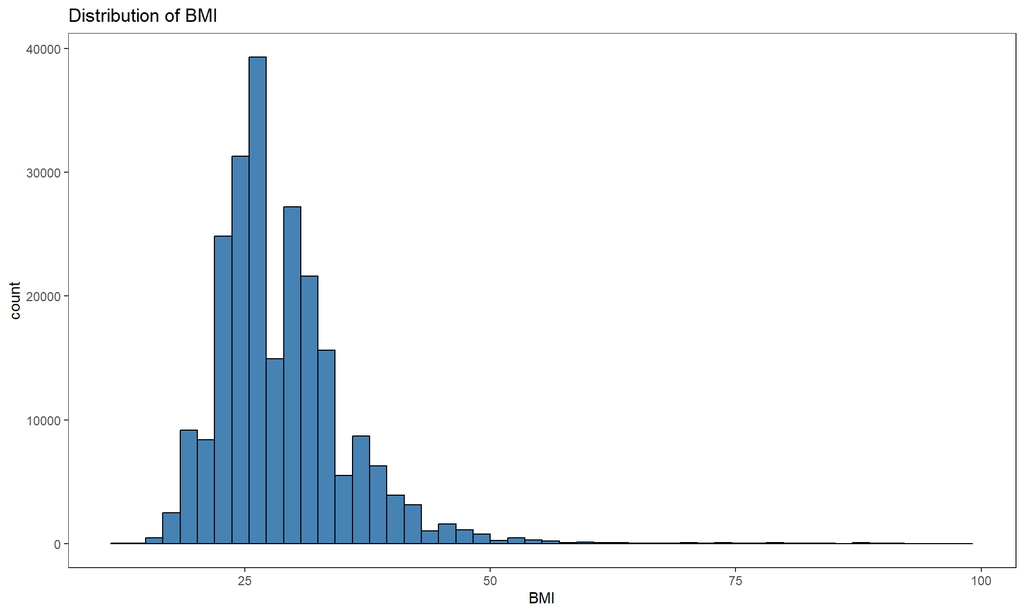

```r
ggplot(diabetes.df, aes(x = BMI)) +
  geom_histogram(bins = 50, fill = "steelblue", color = "black") +
  theme_test() + labs(title = "Distribution of BMI")
```

#### Age Boxplots

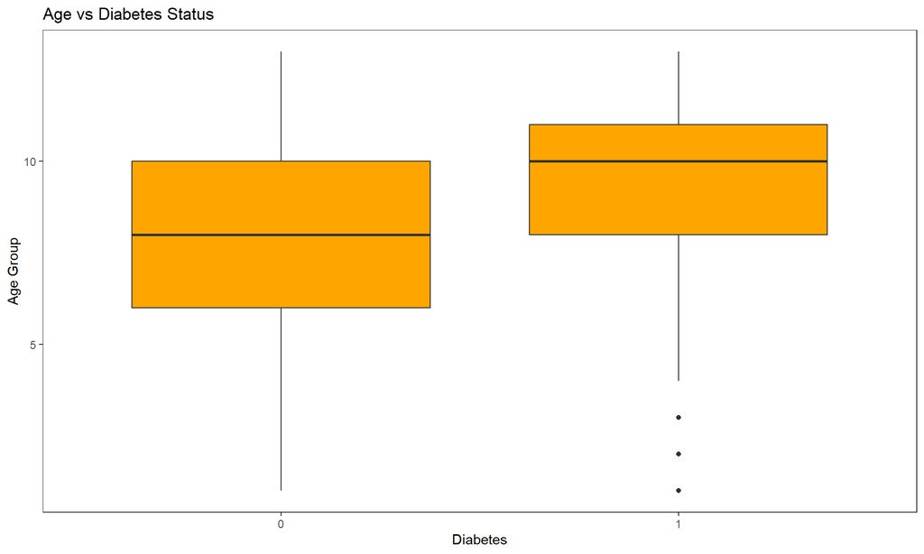

```r
ggplot(diabetes.df, aes(x = as.factor(Diabetes_binary), y = Age)) +
  geom_boxplot(fill = "orange") +
  labs(title = "Age vs Diabetes Status", x = "Diabetes", y = "Age Group") +
  theme_test()
```

#### Correlation among numeric variables

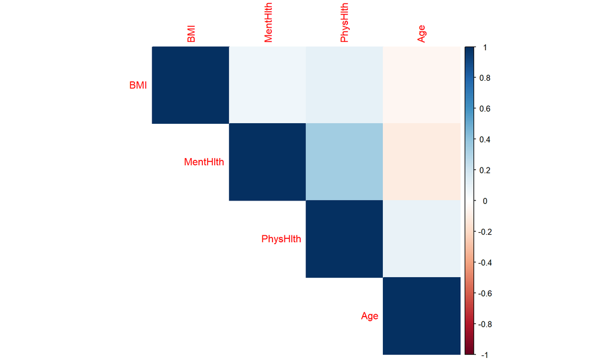

```r
numeric_vars <- diabetes.df %>% select(BMI, MentHlth, PhysHlth, Age)
corrplot(cor(numeric_vars), method = "color", type = "upper")
```

## Data Preparation

### Defensive cleaning

Defensive cleaning for **MentHlth** and **PhysHlth** special codes/ placeholders. In some BRFSS releases, 88 can mean zero **0** days. Hence I will convert 88 to 0 and 77 or 99 to **NA**. If these codes are not present in the dataset, then the mutate() calls are no-ops.

```r
diabetes.df <- diabetes.df |>
  mutate(
    MentHlth = case_when(MentHlth %in% c(88) ~ 0,
                         MentHlth %in% c(77,99) ~ NA,
                         TRUE ~ MentHlth),
    PhysHlth = case_when(PhysHlth %in% c(88) ~ 0,
                         PhysHlth %in% c(77,99) ~ NA,
                         TRUE ~ PhysHlth)
  )
```

### Remove NA’s

Remove rows containing NA’s

```r
diabetes.df <- na.omit(diabetes.df)
```

### Remove Outliers

Remove outliers from BMI using IQR method

```r
# Calculate IQR bounds for BMI
Q1 <- quantile(diabetes.df$BMI, 0.25, na.rm = TRUE)
Q3 <- quantile(diabetes.df$BMI, 0.75, na.rm = TRUE)
IQR <- Q3 - Q1
lower_bound <- Q1 - 1.5 * IQR
upper_bound <- Q3 + 1.5 * IQR

# Remove rows with BMI outliers
diabetes.df <- diabetes.df %>%
  filter(BMI >= lower_bound & BMI <= upper_bound)
```

### Binning Mental and Physical Health

```r
diabetes.df$MentHlth_binned <- cut(diabetes.df$MentHlth,
                                   breaks = c(-1, 0, 10, 20, 30),
                                   labels = c("None", "Low", "Moderate", "High"))
diabetes.df$PhysHlth_binned <- cut(diabetes.df$PhysHlth,
                                   breaks = c(-1, 0, 10, 20, 30),
                                   labels = c("None", "Low", "Moderate", "High"))
```

The code bins the `MentHlth` and `PhysHlth` variables—representing the number of unhealthy days—into four categorical levels: “None,” “Low,” “Moderate,” and “High.” This simplifies analysis, improves interpretability, and supports visualizations or modeling, especially for skewed data. The binning enhances clarity but should be evaluated to ensure meaningful thresholds and balanced group sizes.

### Scale BMI

```r
diabetes.df$BMI_scaled <- scale(diabetes.df$BMI)
```

### Age Grouping

```r
diabetes.df$Age_group <- cut(diabetes.df$Age,
                             breaks = c(0, 4, 8, 13),
                             labels = c("18–34", "35–54", "55+"))
```

### Feature Engineering:

#### Chronic Risk Load

```r
diabetes.df$Chronic_Risk_Load <- with(diabetes.df, HighBP + HighChol +
                                        Stroke + HeartDiseaseorAttack)
```

The `Chronic_Risk_Load` variable is a newly engineered feature that sums four binary health indicators—high blood pressure, high cholesterol, stroke, and heart disease—to reflect an individual’s total chronic disease burden. Ranging from 0 to 4, it provides a simplified, interpretable measure of health risk that can enhance predictive modeling and population stratification. This feature helps capture the compounded effect of comorbidities and supports deeper analysis of how chronic conditions relate to diabetes and other health outcomes.

#### Healthcare Barrier Index

```r
diabetes.df$Healthcare_Barrier_Index <- with(diabetes.df, NoDocbcCost + (1 - AnyHealthcare))
```

The `Healthcare_Barrier_Index` is a new feature that combines lack of insurance and inability to afford doctor visits into a single score ranging from 0 to 2. It captures the extent of healthcare access barriers, with higher values indicating greater difficulty in obtaining care. This index enhances analysis by incorporating structural health risk factors and can be used to examine how access issues relate to health outcomes like diabetes.

### Convert variables to factors

```r
diabetes.df$Sex <- factor(ifelse(diabetes.df$Sex == 1, "Male", "Female"))
diabetes.df$GenHlth <- factor(diabetes.df$GenHlth,
                              levels = 1:5,
                              labels = c("Excellent", "Very good", "Good", "Fair", "Poor"))
diabetes.df$Education <- factor(diabetes.df$Education,
                                levels = 1:6,
                                labels = c("<HS", "HS", "Some college",
                                           "College 1-3y", "College 4y", "Postgrad"))
diabetes.df$Income <- factor(diabetes.df$Income,
                             levels = 1:8,
                             labels = c("<10k", "10-15k", "15-20k", "20-25k",
                                        "25-35k", "35-50k", "50-75k", "75k+"))
```

### Drop unused variables

```r
diabetes.df <- diabetes.df %>%
  select(Diabetes_binary, BMI, BMI_scaled, MentHlth_binned, PhysHlth_binned,
         Age_group, Chronic_Risk_Load, Healthcare_Barrier_Index, GenHlth,
         Education, Income, Smoker, PhysActivity, DiffWalk,
         HvyAlcoholConsump, Sex)
```

### Export to CSV file

Export to CSV file for further visualization

```r
write.csv(diabetes.df, "diabetes_data.csv", row.names = FALSE)
```

### EDA through Visualization

#### Define high-risk group (≥30% probability equivalent proxy)

```r
mean_bmi <- mean(diabetes.df$BMI, na.rm = TRUE)  # mean before scaling
sd_bmi <- sd(diabetes.df$BMI, na.rm = TRUE)      # std before scaling
diabetes.df$approx_BMI <- (diabetes.df$BMI_scaled * sd_bmi) + mean_bmi

# Define high-risk flag
diabetes.df$HighRisk <- ifelse(diabetes.df$approx_BMI > 30 &
                                 diabetes.df$Diabetes_binary == 0, 1, 0)
```

#### 1. KPI-style summary plot

```r
kpi_data <- diabetes.df %>%
  summarise(
    pct_high_risk = mean(HighRisk) * 100,
    total_high_risk = sum(HighRisk),
    avg_BMI_high_risk = mean(approx_BMI[HighRisk == 1]),
    avg_chronic_load = mean(Chronic_Risk_Load[HighRisk == 1])
  )
kable(kpi_data)
```

| pct_high_risk | total_high_risk | avg_BMI_high_risk | avg_chronic_load |
| --- | --- | --- | --- |
| 22.14657 | 49572 | 34.61311 | 1.066409 |

#### 2. Risk by Age & Sex

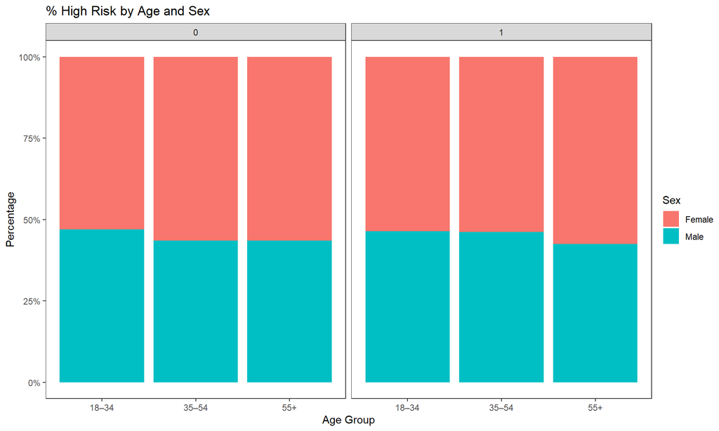

```r
ggplot(diabetes.df, aes(x = Age_group, fill = Sex)) +
  geom_bar(position = "fill") +
  facet_wrap(~HighRisk) +
  scale_y_continuous(labels = percent) +
  labs(
    title = "% High Risk by Age and Sex",
    x = "Age Group", y = "Percentage",
    fill = "Sex"
  ) +
  theme_test()
```

#### 3. Socio-economic Treemap (Education + Income)

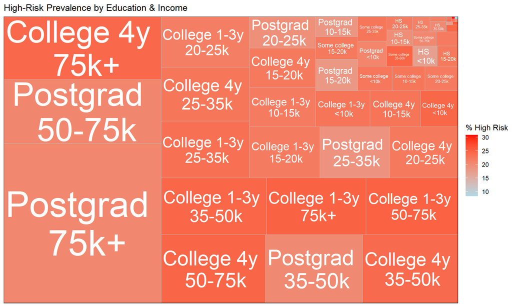

```r
df_treemap <- diabetes.df %>%
  group_by(Education, Income) %>%
  summarise(
    count = n(),
    pct_high_risk = mean(HighRisk) * 100
  )

ggplot(df_treemap, aes(area = count, fill = pct_high_risk,
                       label = paste(Education, "\n", Income))) +
  geom_treemap() +
  geom_treemap_text(colour = "white", place = "centre", grow = TRUE) +
  scale_fill_gradient(low = "lightblue", high = "red") +
  labs(title = "High-Risk Prevalence by Education & Income",
       fill = "% High Risk") +
  theme_test()
```

#### 4. Behavioral & Health Markers

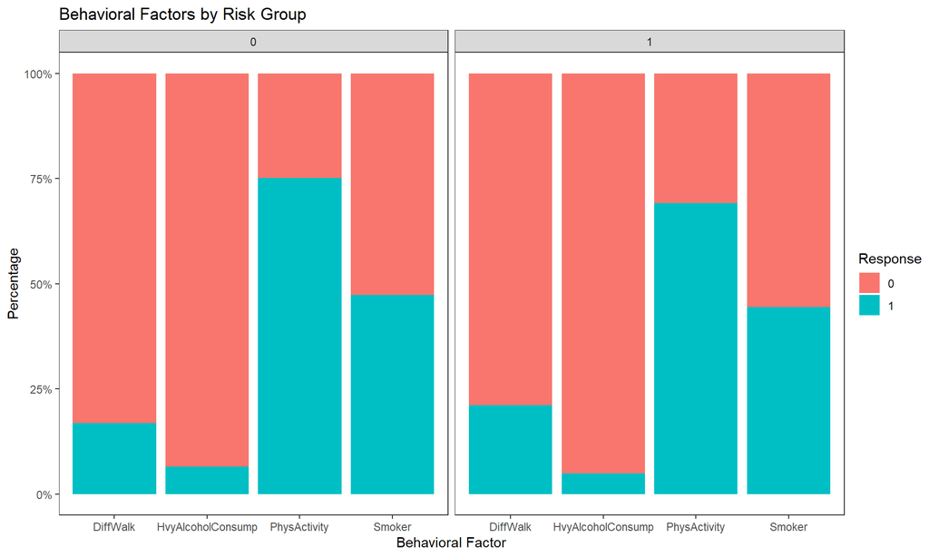

```r
df_long <- diabetes.df %>%
  select(HighRisk, Smoker, PhysActivity, DiffWalk, HvyAlcoholConsump) %>%
  pivot_longer(cols = -HighRisk, names_to = "Behavior", values_to = "Value")

ggplot(df_long, aes(x = Behavior, fill = factor(Value))) +
  geom_bar(position = "fill") +
  facet_wrap(~HighRisk) +
  scale_y_continuous(labels = percent) +
  labs(
    title = "Behavioral Factors by Risk Group",
    x = "Behavioral Factor", y = "Percentage",
    fill = "Response"
  ) +
  theme_test()
```

#### 5. General Health vs Risk

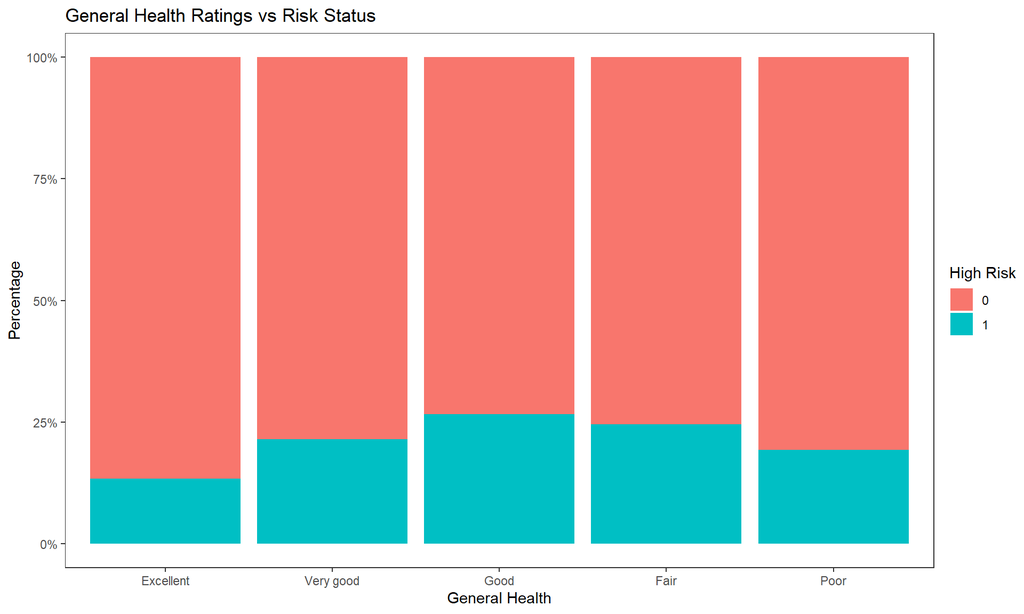

```r
ggplot(diabetes.df, aes(x = GenHlth, fill = factor(HighRisk))) +
  geom_bar(position = "fill") +
  scale_y_continuous(labels = percent) +
  labs(
    title = "General Health Ratings vs Risk Status",
    x = "General Health", y = "Percentage",
    fill = "High Risk"
  ) +
  theme_test()
```

### Convert categorical variables to factor

```r
diabetes.df <- diabetes.df %>%
  mutate(across(where(is.character), as.factor),
         across(c(Diabetes_binary, GenHlth, Education, Income, Smoker, PhysActivity,
                  DiffWalk, HvyAlcoholConsump, Sex, Age_group,
                  MentHlth_binned, PhysHlth_binned), as.factor))
```

### Train/Test split (stratified)

```r
set.seed(123)
train_idx <- createDataPartition(diabetes.df$Diabetes_binary,
                                 p = 0.8, list = FALSE)
train <- diabetes.df[train_idx, ]
test <- diabetes.df[-train_idx, ]
```

## Modeling

### Logistic Regression

This is initial baseline model.

#### Fit logistic model

```r
model_logit <- glm(Diabetes_binary ~ ., data = train, family = binomial)
```

#### Model Summary

```r
summary(model_logit)
```

```
##
## Call:
## glm(formula = Diabetes_binary ~ ., family = binomial, data = train)
##
## Coefficients: (2 not defined because of singularities)
##                            Estimate Std. Error z value Pr(>|z|)
## (Intercept)              -13.160533   0.282759 -46.543  < 2e-16 ***
## BMI                        0.347160   0.002820 123.117  < 2e-16 ***
## BMI_scaled                       NA         NA      NA       NA
## MentHlth_binnedLow        -0.192033   0.023795  -8.070 7.01e-16 ***
## MentHlth_binnedModerate   -0.149890   0.044248  -3.388 0.000705 ***
## MentHlth_binnedHigh       -0.086988   0.038122  -2.282 0.022499 *
## PhysHlth_binnedLow        -0.044299   0.022299  -1.987 0.046966 *
## PhysHlth_binnedModerate   -0.072368   0.039844  -1.816 0.069324 .
## PhysHlth_binnedHigh       -0.081002   0.034675  -2.336 0.019488 *
## Age_group35–54             0.844214   0.046275  18.243  < 2e-16 ***
## Age_group55+               1.315175   0.045824  28.701  < 2e-16 ***
## Chronic_Risk_Load          0.449244   0.009725  46.197  < 2e-16 ***
## Healthcare_Barrier_Index  -0.055649   0.024237  -2.296 0.021673 *
## GenHlthVery good           0.669014   0.040844  16.380  < 2e-16 ***
## GenHlthGood                1.286503   0.040104  32.079  < 2e-16 ***
## GenHlthFair                1.775440   0.044829  39.605  < 2e-16 ***
## GenHlthPoor                1.931642   0.056308  34.305  < 2e-16 ***
## EducationHS               -0.140002   0.268868  -0.521 0.602570
## EducationSome college     -0.263485   0.266243  -0.990 0.322350
## EducationCollege 1-3y     -0.299095   0.264106  -1.132 0.257433
## EducationCollege 4y       -0.268632   0.264232  -1.017 0.309319
## EducationPostgrad         -0.292873   0.264363  -1.108 0.267930
## Income10-15k              -0.008225   0.052510  -0.157 0.875534
## Income15-20k              -0.091193   0.050326  -1.812 0.069978 .
## Income20-25k              -0.105882   0.048913  -2.165 0.030411 *
## Income25-35k              -0.189353   0.048207  -3.928 8.57e-05 ***
## Income35-50k              -0.289507   0.047480  -6.097 1.08e-09 ***
## Income50-75k              -0.329300   0.047974  -6.864 6.69e-12 ***
## Income75k+                -0.391586   0.047259  -8.286  < 2e-16 ***
## Smoker1                   -0.057497   0.018371  -3.130 0.001750 **
## PhysActivity1             -0.033506   0.020159  -1.662 0.096502 .
## DiffWalk1                  0.152410   0.024221   6.293 3.12e-10 ***
## HvyAlcoholConsump1        -0.762258   0.048961 -15.569  < 2e-16 ***
## SexMale                    0.119168   0.018557   6.422 1.35e-10 ***
## approx_BMI                       NA         NA      NA       NA
## HighRisk                 -21.354098  46.184126  -0.462 0.643817
## ---
## Signif. codes:  0 '***' 0.001 '**' 0.01 '*' 0.05 '.' 0.1 ' ' 1
##
## (Dispersion parameter for binomial family taken to be 1)
##
##     Null deviance: 150066  on 179068  degrees of freedom
## Residual deviance:  83251  on 179035  degrees of freedom
## AIC: 83319
##
## Number of Fisher Scoring iterations: 18
```

#### Predict probabilities and classes

```r
test_probs <- predict(model_logit, newdata = test, type = "response")
test_pred <- ifelse(test_probs > 0.5, 1, 0)
```

#### Evaluate logistic model

```r
confusionMatrix(as.factor(test_pred), test$Diabetes_binary, positive = "1")
```

```
## Confusion Matrix and Statistics
##
##           Reference
## Prediction     0     1
##          0 37315  3140
##          1   832  3480
##
##                Accuracy : 0.9113
##                  95% CI : (0.9086, 0.9139)
##     No Information Rate : 0.8521
##     P-Value [Acc > NIR] : < 2.2e-16
##
##                   Kappa : 0.5887
##
##  Mcnemar's Test P-Value : < 2.2e-16
##
##             Sensitivity : 0.52568
##             Specificity : 0.97819
##          Pos Pred Value : 0.80705
##          Neg Pred Value : 0.92238
##              Prevalence : 0.14788
##          Detection Rate : 0.07774
##    Detection Prevalence : 0.09632
##       Balanced Accuracy : 0.75193
##
##        'Positive' Class : 1
##
```

#### Logistic ROC curve

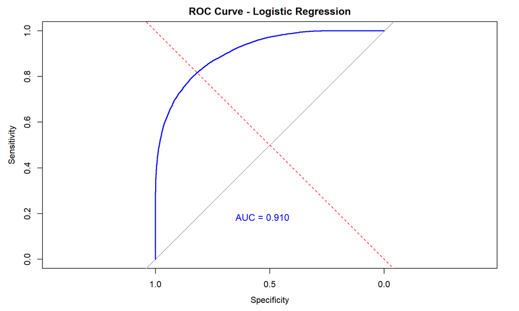

```r
roc_obj <- roc(response = test$Diabetes_binary, predictor = test_probs, quiet = TRUE)

plot(roc_obj,
     main = "ROC Curve - Logistic Regression",
     col = "blue",
     lwd = 2,
     print.auc = TRUE,
     print.auc.pattern = "AUC = %.3f",
     print.auc.cex = 1.1,
     print.auc.x = 0.65, print.auc.y = 0.2)
abline(a = 0, b = 1, lty = 2, col = "red")
```